# Prediction Assignment

Sujit Das

May 29, 2017

## Executive Summary

The goal of this project is to use data from accelerometers on the belt, forearm, arm and dumbell of 6 participants, and predict the manner in which they did the exercise.

Multiple prediction models were used and the model that was selected for the final prediction model had highest accuracy.

## Data Partioning and Exploration

For training and prediction, the data set was split into training (70% of data) and testing data set (remaining 30%).

```r
fileURL <- "https://d396qusza40orc.cloudfront.net/predmachlearn/pml-training.csv"
download.file(fileURL, destfile = "./pml-training.csv")
dateDownloaded <- date()

trainData <- read.csv("./pml-training.csv", header = TRUE, na.strings =
                              c("", "#DIV/0!", "NA"), row.names = NULL)
trainData$classe <- as.factor(trainData$classe)

library(caret)
set.seed(1235)
inTrain <- createDataPartition(trainData$classe, p = 0.7, list = FALSE)
trainSet <- trainData[inTrain, ]
testSet <- trainData[-inTrain, ]
```

The data was downloaded on Mon May 29 21:00:43 2017. After data partioning, each data set had following records:

- Number of records from the training data set = 13737
- Number of records from the testing data set = 5885

The downloaded data was first manually inspected. It had several columns with NA values. These columns were first identified and then removed from the list of potential predictors for the classe outcome variable.

```r
colsOrig <- ncol(trainSet)
nzv <- nearZeroVar(trainSet)
trainSet <- trainSet[, -nzv]
colsNZV <- ncol(trainSet)

naData <- apply(trainSet, 2, function(col) sum(is.na(col))/length(col))

## Consider only those columns that have number of NAs less than 50%
subNAData <- naData[naData < 0.5]

## Remove first column as it just sequnce number
subNAData <- subNAData[c(-1)]
trainSet <- trainSet[, names(subNAData)]
```

The number of predictors to be used in training model has been reduced as below:

- Number of predictors originally available in the data set = 160
- Number of predictors after applying near zero variance function = 127
- Number of predictors after removing columns with NAs >= 50% & first column = 58

## Building Prediction Models

Below models were trained on the training data set

We used the basic version of cross-validation - k-fold cross-validation. Here, the samples are randomly partitioned into k sets (called folds) of roughly equal size. A model is fit using all the samples except the first subset. Then, the prediction error of the fitted model is calculated using the first held-out samples. The same operation is repeated for each fold and the model’s performance is calculated by averaging the errors across the different test sets. k was fixed at 3.

```r
train_control <- trainControl(method="cv", number=3)
vecModelName <- c("Classification.Tree", "Random.Forest","Boosted.Predictor",
                  "Bagging.Predictor", "Combining.Predictor")
vecModelMethod <- c("rpart", "rf", "gbm", "treebag", "gam")
vecAccuracy <- vector(mode = "numeric", length = 5)
listModel <- list()
listResult <- list()

## Predict using for all 5 prediction models as well as determine its
## accuracy
for (indx in 1:4)       {
        listModel[[indx]] <- train(classe ~ ., data = trainSet,
                                   trControl=train_control,
                                   method=vecModelMethod[indx])
        listResult[[indx]] <- predict(listModel[[indx]], testSet)
        vecAccuracy[indx] <- confusionMatrix(testSet$classe,
                                listResult[[indx]])$overall['Accuracy'][[1]]
}

## Prediction model that combines Random Forest, Boosted Predictor and Bagging
## predictor
predDF <- data.frame(listResult[[2]], listResult[[3]], listResult[[4]],
                     classe = testSet$classe)
listModel[[5]] <- train(classe ~ ., data = predDF, trControl=train_control,
                        method="gam")
listResult[[5]] <- predict(listModel[[5]], predDF)
vecAccuracy[5] <- confusionMatrix(testSet$classe,
                                  listResult[[5]])$overall['Accuracy'][[1]]
```

## Select Prediction Model

Since ‘classe’ is a categorical variable, the prediction model with the highest accuracy was selected as the final model. Below shows prediction model plots along with the accuracy table.

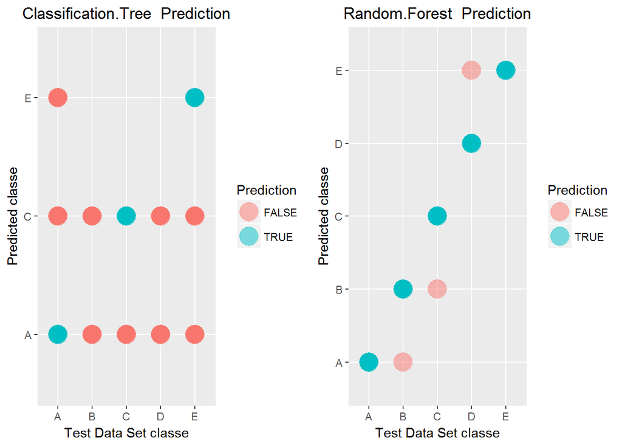

```r
g <- list()
## Plot prediction of each model for test data set
for (indx in 1:5)       {
        predRight <- listResult[[indx]] == testSet$classe
        plotDF <- data.frame(x = testSet$classe, y = listResult[[indx]],
                             Prediction = predRight)
        g[[indx]] <- ggplot(data = plotDF, aes(y = y, x = x,
                                               colour = Prediction))
        g[[indx]] <- g[[indx]] + geom_point(size = 7, alpha = 0.5)
        g[[indx]] <- g[[indx]] + xlab("Test Data Set classe") +
                                 ylab("Predicted classe")
        g[[indx]] <- g[[indx]] + ggtitle(paste(vecModelName[indx],
                                               " Prediction"))
        g[[indx]] <- g[[indx]] + theme(plot.title = element_text(hjust = 0.5))
}

library(gridExtra)
grid.arrange(g[[1]], g[[2]], ncol = 2)
```

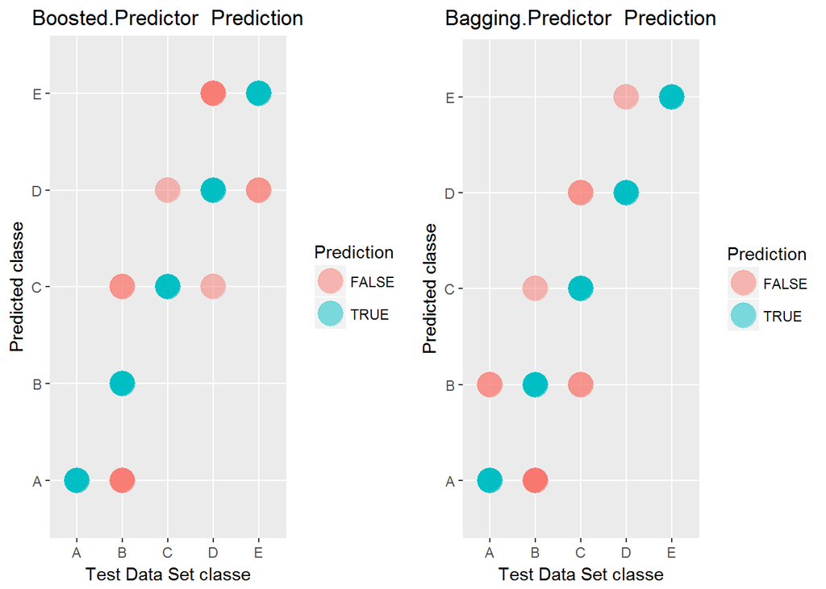

```r
grid.arrange(g[[3]], g[[4]], ncol = 2)
```

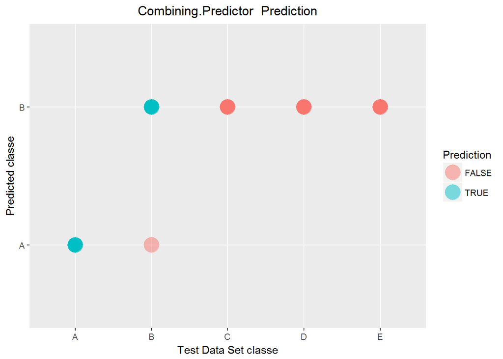

```r
grid.arrange(g[[5]], ncol = 1)
```

```r
## Print the prediction accuracy for each of the 5 models
library(knitr)
dfAccuracy <- data.frame("Accuracy" = vecAccuracy, row.names = vecModelName)
kable(round(dfAccuracy, 4), align = "c", caption = "Predictor Accuracy")
```

Predictor Accuracy

|  | Accuracy |
| --- | --- |
| Classification.Tree | 0.4664 |
| Random.Forest | 0.9995 |
| Boosted.Predictor | 0.9976 |
| Bagging.Predictor | 0.9976 |
| Combining.Predictor | 0.4778 |

Based on the prediction accuracy, the final selected prediction model was **Random Forest since it had the highest accuracy of 0.9995**